# Coca-Cola (KO): ¿le conviene emitir un bono convertible?

Productos Derivados — Avance 1 del proyecto final

Equipo 8: Maria Cecilia Cantú, Melissa Arizoca, Valeria Acosta

Datos de LSEG Workspace al 25 de octubre de 2026

**Situación problema.** En 2007 Deutsche Bank estructuró para Molson Coors un bono convertible de US$575 millones a 6 años, con prima de conversión de 25% y cupón de 2.5%, para recomprar bonos caros de 6.38%. Además, Molson compró una cobertura (*call spread*) que llevó la prima efectiva a 60%. En este proyecto aplicamos la misma lógica a **Coca-Cola (KO)**: ¿le conviene financiarse con un convertible en lugar de deuda tradicional?, ¿con qué prima y qué cupón?, ¿y cuánto costaría una cobertura como la de Molson?

Este avance reúne los datos de LSEG que vamos a usar (empresa, deuda, calificación y tasas) y un primer cálculo del convertible.

## 1. Resumen de la empresa

```r
# ---- Datos de la pantalla Overview y FOV de LSEG (25-oct-2026; precio al cierre del 23-oct) ----
precio      <- 92.71
market_cap  <- 398.889      # miles de millones de USD
acciones    <- 4.30         # miles de millones
div_yield   <- 0.0229
beta        <- 0.29
pe_ltm      <- 27.93
cds_5y      <- 35.60        # puntos base

# ---- Precio histórico diario (exportado de LSEG: Price & Charts > Price History, 2 años) ----
ph <- read_excel("datos/KO_price_history.xlsx", col_names = FALSE)
inicio <- which(ph[[1]] == "Exchange Date")
precios <- ph[(inicio + 1):nrow(ph), 1:2] %>%
  setNames(c("fecha", "cierre")) %>%
  mutate(fecha = as.Date(as.numeric(fecha), origin = "1899-12-30"), cierre = as.numeric(cierre)) %>%
  filter(!is.na(fecha), !is.na(cierre)) %>%
  arrange(fecha) %>%
  mutate(rend = log(cierre / lag(cierre)))

vol_1a <- sd(tail(precios$rend, 252), na.rm = TRUE) * sqrt(252)
vol_2a <- sd(precios$rend, na.rm = TRUE) * sqrt(252)
```

US$92.71

Precio de la acción

Cierre del 23-oct-2026

US$398.9 mil M

Valor de mercado

4.3 mil millones de acciones

2.29%

Rendimiento por dividendo

Clave para valuar la opción

19.1%

Volatilidad histórica (1 año)

2 años: 18.3%

0.29

Beta (5 años)

Se mueve mucho menos que el mercado

27.93

Precio / utilidad (P/E)

Últimos 12 meses

```r
plot_ly(precios, x = ~fecha, y = ~cierre, type = "scatter", mode = "lines",
        line = list(color = "#C8102E"), hovertemplate = "%{x}<br>US$%{y:.2f}<extra></extra>") %>%
  layout(title = list(text = "Precio de KO — últimos 2 años (LSEG)", font = list(size = 15)),
         xaxis = list(title = ""), yaxis = list(title = "USD por acción"))
```

[interactive chart not shown]

```r
# Resumen financiero de la pantalla FOV (miles de millones de USD); FY2026 es el pronóstico promedio de analistas (I/B/E/S)
financieros <- tribble(
  ~Concepto,            ~`FY2024`, ~`FY2025`, ~`Últimos 12 meses`, ~`FY2026 (pronóstico)`,
  "Ventas",              46.90,     48.06,     50.07,               49.80,
  "EBITDA",              15.16,     16.06,     16.94,               17.39,
  "Margen EBITDA (%)",   32.33,     33.42,     33.82,               34.92,
  "Utilidad neta",       12.46,     12.96,     13.94,               14.26,
  "Margen neto (%)",     26.58,     26.96,     27.84,               28.63,
  "Utilidad por acción", 2.88,      3.00,      3.23,                3.31
)
datatable(financieros, rownames = FALSE, options = list(dom = "t", ordering = FALSE),
          caption = "Resumen financiero de KO (miles de millones de USD, salvo márgenes y utilidad por acción). Fuente: LSEG, pantalla FOV.") %>%
  formatRound(2:5, 2)
```

| Concepto | FY2024 | FY2025 | Últimos 12 meses | FY2026 (pronóstico) |
| --- | --- | --- | --- | --- |
| Ventas | 46.9 | 48.06 | 50.07 | 49.8 |
| EBITDA | 15.16 | 16.06 | 16.94 | 17.39 |
| Margen EBITDA (%) | 32.33 | 33.42 | 33.82 | 34.92 |
| Utilidad neta | 12.46 | 12.96 | 13.94 | 14.26 |
| Margen neto (%) | 26.58 | 26.96 | 27.84 | 28.63 |
| Utilidad por acción | 2.88 | 3 | 3.23 | 3.31 |

**Lectura.** Coca-Cola es una empresa grande, estable y muy rentable: vende cerca de US$50 mil millones al año con un margen neto de 28%. Su acción se mueve poco comparada con el mercado (beta de 0.29) y tiene una volatilidad de 19.1%, baja para una acción. En lo que va del año subió 33% y está cerca de su máximo de 52 semanas. Dos datos son clave para el convertible: la volatilidad baja y el dividendo de 2.29%. Los dos hacen que la opción de conversión valga menos que en el caso de Molson.

## 2. Deuda

```r
# ---- Pantalla FOV (millones de USD) ----
deuda_total <- 43543; caja <- 12907; inversiones_cp <- 3464
deuda_ebitda <- 2.83; ebitda_intereses <- 9.72; deuda_capital <- 1.2045
deuda_neta <- deuda_total - caja - inversiones_cp

# ---- Lista de bonos (LSEG: Debt & Credit > Debt Structure, exportado) ----
bonos <- read_excel("datos/KO_bonos.xlsx", sheet = "Bonds", skip = 1) %>%
  transmute(Bono = str_trim(Description),
            Vencimiento = if (is.numeric(`Maturity Date`)) as.Date(`Maturity Date`, origin = "1899-12-30") else as.Date(`Maturity Date`),
            Monto_MM = `Amount Outstanding` / 1e6, Cupon = Coupon, Moneda = Currency,
            Tipo = `Instrument Type`, Precio = `Last Price`, Rendimiento = Yield) %>%
  filter(Monto_MM > 0)
```

US$43.5 mil M

Deuda total

US$16.4 mil M

Caja e inversiones de corto plazo

US$27.2 mil M

Deuda neta

2.83x

Deuda / EBITDA (FY2025)

Años de EBITDA para pagar la deuda

9.72x

EBITDA / intereses (FY2025)

Veces que el EBITDA cubre los intereses

48 bonos

Emisiones vigentes

US$41.9 mil M en circulación

```r
perfil <- bonos %>%
  mutate(Año = year(Vencimiento),
         Moneda = case_when(str_detect(Moneda, "US") ~ "Dólares", str_detect(Moneda, "Euro") ~ "Euros", TRUE ~ "Francos suizos")) %>%
  filter(Año <= 2041) %>%
  group_by(Año, Moneda) %>% summarise(Monto = sum(Monto_MM), .groups = "drop")

plot_ly(perfil, x = ~Año, y = ~Monto, color = ~Moneda, colors = c("#1F3B5C", "#C8102E", "#9aa5b1"), type = "bar",
        hovertemplate = "%{x}: US$%{y:,.0f} M<extra></extra>") %>%
  layout(barmode = "stack", title = list(text = "Perfil de vencimientos de los bonos de KO (millones de USD)", font = list(size = 15)),
         xaxis = list(title = "", dtick = 1), yaxis = list(title = "Millones de USD"),
         annotations = list(list(x = 2027, y = 4900, text = "US$3,000 M en dólares<br>vencen en 2027", showarrow = TRUE, ay = -40)))
```

[interactive chart not shown]

```r
datatable(bonos %>% arrange(Vencimiento) %>% mutate(Vencimiento = format(Vencimiento, "%d-%b-%Y")),
          rownames = FALSE, options = list(pageLength = 10, scrollX = TRUE),
          colnames = c("Bono", "Vencimiento", "Monto (MM)", "Cupón (%)", "Moneda", "Tipo", "Precio", "Rendimiento (%)"),
          caption = "Bonos vigentes de Coca-Cola (LSEG). Los montos están en millones de la moneda del bono.") %>%
  formatRound(c("Monto_MM"), 0) %>% formatRound(c("Precio", "Rendimiento"), 2)
```

| Bono | Vencimiento | Monto (MM) | Cupón (%) | Moneda | Tipo | Precio | Rendimiento (%) |
| --- | --- | --- | --- | --- | --- | --- | --- |
| KOCCE / KO 6.950 15-Nov-2026 | 15-Nov-2026 | 151.717 | 6.95 | US Dollar | Debenture | 100.1293 | 4.401716 |
| KO 1.125 09-Mar-2027 '26 | 09-Mar-2027 | 1680.3 | 1.125 | Euro | Note | 99.284 | 3.089991 |
| KO 3.375 25-Mar-2027 | 25-Mar-2027 | 1000 | 3.375 | US Dollar | Note | 99.5553 | 4.456309 |
| KO 2.900 25-May-2027 | 25-May-2027 | 500 | 2.9 | US Dollar | Note | 99.1054 | 4.474376 |
| KO 1.450 01-Jun-2027 | 01-Jun-2027 | 1500 | 1.45 | US Dollar | Note | 98.181 | 4.569978 |
| KO 1.500 05-Mar-2028 | 05-Mar-2028 | 750 | 1.5 | US Dollar | Note | 95.7523 | 4.765155 |
| KO 1.000 15-Mar-2028 | 15-Mar-2028 | 1300 | 1 | US Dollar | Note | 94.9075 | 4.842107 |
| KOCCE / KO 6.750 15-Sep-2028 | 15-Sep-2028 | 131.351 | 6.75 | US Dollar | Debenture | 102.5435 | 5.310604 |
| KO 1.000 02-Oct-2028 | 02-Oct-2028 | 697.054188 | 1 | Swiss Franc | Bond | 100.486 | 0.745381 |
| KO 0.125 09-Mar-2029 | 09-Mar-2029 | 784.14 | 0.125 | Euro | Note | 92.287 | 3.585251 |

[output cut: 38 more lines]

**Lectura.** KO tiene una deuda manejable: equivale a 2.8 años de EBITDA y su EBITDA cubre casi 10 veces los intereses. Su deuda está repartida en 48 bonos en dólares, euros y francos suizos, con vencimientos que llegan hasta 2098.

**Uso de los fondos (equivalente al *tender* de Molson).** En 2027 vencen **tres bonos en dólares por US$3,000 millones**: 3.375% (marzo), 2.900% (mayo) y 1.450% (junio). Esa deuda se contrató cuando las tasas eran bajas, y para refinanciarla hoy con un bono tradicional a 6 años KO pagaría alrededor de 5.1%. Proponemos que el convertible financie justamente ese refinanciamiento: emitir **US$3,000 millones** y recomprar esos bonos a precio de mercado (entre 98 y 99.6 por cada 100), como Molson hizo con sus bonos de 6.38%.

## 3. Calificación y tasas

```r
calif <- read_excel("datos/KO_calificaciones.xlsx", skip = 4) %>%
  select(Tipo = 1, Calificación = 2, Fecha = 3, Perspectiva = 6) %>%
  filter(!is.na(Tipo), str_detect(Tipo, "\\(Foreign\\)"),
         str_detect(Tipo, "S&P Long-term Issuer|S&P Senior Unsecured|Moody's Senior Unsecured|Moody's Derived Long-term|Fitch Long-term Issuer Default")) %>%
  mutate(Agencia = str_extract(Tipo, "S&P|Moody's|Fitch"),
         Tipo = str_remove_all(Tipo, "S&P |Moody's |Fitch | \\[.*\\]| \\(Foreign\\)"),
         Perspectiva = recode(Perspectiva, "STABLE" = "Estable", "STA" = "Estable", "--" = "—")) %>%
  select(Agencia, Tipo, Calificación, Fecha, Perspectiva)

datatable(calif, rownames = FALSE, options = list(dom = "t", pageLength = 20, ordering = FALSE),
          caption = "Calificaciones de Coca-Cola (LSEG, Issuer Ratings). WD = calificación retirada por la agencia.")
```

| Agencia | Tipo | Calificación | Fecha | Perspectiva |
| --- | --- | --- | --- | --- |
| S&amp;P | Senior Unsecured | A+ | 26-Apr-2018 | — |
| S&amp;P | Long-term Issuer Rating | A+ | 26-Apr-2018 | Estable |
| Moody's | Senior Unsecured | A1 | 20-Nov-2018 | — |
| Moody's | Derived Long-term Issuer Rating | A1 | 06-Jun-2023 | Estable |
| Fitch | Long-term Issuer Default Rating | WD | 15-Nov-2023 | — |

```r
# ---- Treasuries (LSEG: US5YT=RR y US7YT=RR, rendimiento ask al 25-oct-2026) ----
tesoro <- tibble(Plazo = c(5, 7), Bono = c("UST 5.000% 30-sep-2031", "UST 5.000% 30-sep-2033"),
                 Rendimiento = c(4.7852, 4.8692))
r_6a <- mean(tesoro$Rendimiento) / 100            # tasa libre de riesgo a 6 años (promedio de 5 y 7)

# ---- Rendimiento de los bonos de KO en dólares (tasa de descuento del bono simple) ----
ko_usd <- bonos %>% filter(str_detect(Moneda, "US"), Tipo == "Note", Vencimiento < as.Date("2041-01-01")) %>%
  mutate(Plazo = as.numeric(Vencimiento - as.Date("2026-10-25")) / 365.25)
y_6a <- ko_usd %>% filter(between(Plazo, 4.3, 5.3)) %>% summarise(mean(Rendimiento)) %>% pull() / 100
spread_pb <- (y_6a - r_6a) * 10000
```

A+ / A1

Calificación S&P / Moody's

Perspectiva estable en ambas

35.6 pb

CDS a 5 años

Costo de asegurarse contra un impago de KO

4.83%

Tasa libre de riesgo a 6 años

Promedio de Treasuries a 5 y 7 años

5.09%

Tasa de un bono simple de KO a ~6 años

Promedio de sus bonos 2031–2032

27 pb

Spread sobre el Tesoro

Lo que el mercado cobra extra por prestarle a KO

```r
plot_ly() %>%
  add_markers(data = ko_usd, x = ~Plazo, y = ~Rendimiento, name = "Bonos de KO en USD",
              marker = list(color = "#C8102E", size = 9), text = ~Bono, hovertemplate = "%{text}<br>%{y:.2f}%<extra></extra>") %>%
  add_trace(data = tesoro, x = ~Plazo, y = ~Rendimiento, name = "Bonos del Tesoro", type = "scatter", mode = "markers+lines",
            marker = list(color = "#1F3B5C", size = 10, symbol = "diamond"), line = list(color = "#1F3B5C")) %>%
  layout(title = list(text = "Rendimiento de los bonos de KO vs. bonos del Tesoro de EE. UU.", font = list(size = 15)),
         xaxis = list(title = "Años al vencimiento"), yaxis = list(title = "Rendimiento (%)"))
```

[interactive chart not shown]

**Lectura.** Coca-Cola tiene calificación A+ (S&P) y A1 (Moody’s), ambas con perspectiva estable, y su CDS de 36 puntos base indica que el mercado ve muy poco riesgo de impago. Por eso puede pedir prestado a solo 27 puntos base por arriba del gobierno de EE. UU. Para el convertible usamos dos tasas: **4.83%** como tasa libre de riesgo (para valuar la opción) y **5.09%** como tasa de descuento del bono simple (el equivalente al 5.75% del caso Molson).

## 4. Convertible

```r
# ---- Supuestos (cambiar aquí para hacer escenarios) ----
S       <- precio         # precio de KO
q       <- div_yield      # rendimiento por dividendo
sigma   <- vol_1a         # volatilidad histórica de 1 año
r       <- r_6a           # tasa libre de riesgo a 6 años
y_bono  <- y_6a           # tasa de descuento del bono simple de KO
T       <- 6              # años al vencimiento, igual que Molson
prima   <- 0.25           # prima de conversión propuesta
emision <- 3000           # millones de USD

# Black-Scholes para un call europeo con dividendo continuo
bs_call <- function(S, K, T, r, q, sigma) {
  d1 <- (log(S / K) + (r - q + sigma^2 / 2) * T) / (sigma * sqrt(T)); d2 <- d1 - sigma * sqrt(T)
  S * exp(-q * T) * pnorm(d1) - K * exp(-r * T) * pnorm(d2)
}
# Valor de un bono de 1,000 con cupón semestral
valor_bono <- function(cupon, y, T = 6) {
  n <- T * 2; i <- y / 2
  sum(1000 * cupon / 2 / (1 + i)^(1:n)) + 1000 / (1 + i)^n
}
# Cupón que hace que el convertible valga exactamente 1,000
cupon_equilibrio <- function(valor_opcion_bono, y) uniroot(function(c) valor_bono(c, y) - (1000 - valor_opcion_bono), c(-0.1, 0.2))$root

valuar <- function(prima, q = div_yield, sigma = vol_1a) {
  K <- S * (1 + prima); acciones_bono <- 1000 / K
  opcion <- bs_call(S, K, T, r, q, sigma) * acciones_bono
  cupon <- cupon_equilibrio(opcion, y_bono)
  tibble(prima, K, acciones_bono, opcion, bono = 1000 - opcion, cupon)
}

base <- valuar(prima)
sin_div <- valuar(prima, q = 0)
ahorro_anual <- (y_bono - base$cupon) * emision
```

US$115.89

Precio de conversión

Prima de 25% sobre US$92.71

8.63

Acciones por cada bono de US$1,000

US$109.3

Valor de la opción por bono

Black-Scholes con dividendo

US$890.7

Valor del bono simple

Descontado al 5.09%

2.96%

Cupón del convertible

vs. 5.09% de un bono tradicional

US$64 M

Ahorro de intereses al año

Sobre US$3,000 M

**Cómo se calcula.** Igual que en el caso Molson, el convertible se separa en dos piezas: un **bono simple** más una **opción call** sobre las acciones de KO. Con una prima de 25%, el inversionista puede cambiar su bono por acciones a US$115.89, es decir, 8.63 acciones por cada bono de US$1,000. Valuamos la opción con Black-Scholes (US$109.3 por bono) y buscamos el cupón con el que el bono simple vale lo que falta para llegar a US$1,000: **2.96%**.

```r
molson <- tibble(Concepto = c("Precio de la acción", "Prima de conversión", "Volatilidad", "Dividendo", "Tasa libre de riesgo", "Tasa del bono simple",
                              "Valor de la opción por bono", "Valor del bono simple", "Cupón del convertible"),
                 `Molson (2007)` = c("US$87.61", "25%", "23%", "No se considera", "4.46%", "5.75%", "US$191.5", "US$808.5", "1.93%"),
                 `KO con dividendo` = c(usd(S, 2), pct(prima, 0), pct(sigma, 1), pct(q), pct(r), pct(y_bono),
                                        usd(base$opcion, 1), usd(base$bono, 1), pct(base$cupon)),
                 `KO sin dividendo` = c(usd(S, 2), pct(prima, 0), pct(sigma, 1), "0%", pct(r), pct(y_bono),
                                        usd(sin_div$opcion, 1), usd(sin_div$bono, 1), pct(sin_div$cupon)))
datatable(molson, rownames = FALSE, options = list(dom = "t", ordering = FALSE, pageLength = 20),
          caption = "Mismo cálculo que el caso Molson, aplicado a KO")
```

| Concepto | Molson (2007) | KO con dividendo | KO sin dividendo |
| --- | --- | --- | --- |
| Precio de la acción | US$87.61 | US$92.71 | US$92.71 |
| Prima de conversión | 25% | 25% | 25% |
| Volatilidad | 23% | 19.1% | 19.1% |
| Dividendo | No se considera | 2.29% | 0% |
| Tasa libre de riesgo | 4.46% | 4.83% | 4.83% |
| Tasa del bono simple | 5.75% | 5.09% | 5.09% |
| Valor de la opción por bono | US$191.5 | US$109.3 | US$170.0 |
| Valor del bono simple | US$808.5 | US$890.7 | US$830.0 |
| Cupón del convertible | 1.93% | 2.96% | 1.77% |

```r
curva <- map_dfr(seq(0.10, 0.80, by = 0.05), function(p) bind_rows(
  valuar(p) %>% mutate(Escenario = "KO con dividendo"),
  valuar(p, q = 0) %>% mutate(Escenario = "KO sin dividendo (modelo del caso)")))

plot_ly(curva, x = ~prima * 100, y = ~cupon * 100, color = ~Escenario, colors = c("#C8102E", "#9aa5b1"),
        type = "scatter", mode = "lines+markers", hovertemplate = "Prima %{x:.0f}%: cupón %{y:.2f}%<extra></extra>") %>%
  add_lines(x = c(10, 80), y = rep(y_bono * 100, 2), name = "Bono tradicional de KO", inherit = FALSE,
            line = list(color = "#1F3B5C", dash = "dash")) %>%
  layout(title = list(text = "Cupón del convertible según la prima de conversión", font = list(size = 15)),
         xaxis = list(title = "Prima de conversión (%)"), yaxis = list(title = "Cupón (%)"))
```

[interactive chart not shown]

```r
sens <- expand_grid(Volatilidad = c(0.17, vol_1a, 0.21, 0.23), Prima = c(0.15, 0.25, 0.40, 0.60)) %>%
  mutate(Cupon = map2_dbl(Prima, Volatilidad, ~ valuar(.x, sigma = .y)$cupon)) %>%
  mutate(Volatilidad = pct(Volatilidad, 1), Prima = paste("Prima", pct(Prima, 0))) %>%
  pivot_wider(names_from = Prima, values_from = Cupon)
datatable(sens, rownames = FALSE, options = list(dom = "t", ordering = FALSE),
          caption = "Cupón del convertible por volatilidad y prima (con dividendo)") %>%
  formatPercentage(2:5, 2)
```

| Volatilidad | Prima 15% | Prima 25% | Prima 40% | Prima 60% |
| --- | --- | --- | --- | --- |
| 17.0% | 0.02572339786699446 | 0.03230763542224208 | 0.0390572415707458 | 0.04436056338233846 |
| 19.1% | 0.02283785294375176 | 0.02957439908912937 | 0.03665969939677821 | 0.04247289049717162 |
| 21.0% | 0.02012288096565611 | 0.02699658404845715 | 0.03436623763030525 | 0.0406069848047963 |
| 23.0% | 0.01734787492962739 | 0.0243571778895405 | 0.03199360621066424 | 0.03862993978326765 |

**Lectura.**

- **El dividendo cambia mucho el resultado.** Como el dueño del convertible no recibe dividendos mientras no convierta, la opción vale menos: US$109.3 por bono con dividendo contra US$170 sin él. Por eso el cupón de equilibrio sube de 1.77% a 2.96%. Si usáramos el modelo del caso Molson, que no toma en cuenta el dividendo, propondríamos un cupón demasiado bajo y el bono no se vendería a su valor.
- **Aun así, KO ahorra.** Con prima de 25% y cupón de 2.96%, KO pagaría 214 puntos base menos que con un bono tradicional: unos **US$64 millones al año** sobre US$3,000 millones.
- **Entre más alta la prima, menor el ahorro.** Con prima de 60% el cupón sube a 4.25%, cerca del costo de la deuda tradicional.
- **Dilución pequeña.** Si todos convirtieran, KO emitiría unos 25.9 millones de acciones nuevas, apenas 0.60% de las acciones actuales.

## 5. Cobertura (call spread)

```r
K1 <- S * 1.25; K2 <- S * 1.60
acciones_conv <- emision / K1                                  # millones de acciones del convertible
costo_cobertura <- bs_call(S, K1, T, r, q, sigma) * acciones_conv
ingreso_warrants <- bs_call(S, K2, T, r, q, sigma) * acciones_conv
neto <- ingreso_warrants - costo_cobertura

spread <- tibble(
  Concepto = c("Compra de calls a 125% (cobertura del convertible)", "Venta de warrants a 160%", "Costo neto", "Costo neto como % de la emisión"),
  `KO (millones USD)` = c(-costo_cobertura, ingreso_warrants, neto, NA),
  `KO (% de la emisión)` = c(-costo_cobertura, ingreso_warrants, neto, neto) / emision,
  `Molson (% de la emisión)` = c(-0.186, 0.099, -0.086, -0.086))
datatable(spread[1:3, ], rownames = FALSE, options = list(dom = "t", ordering = FALSE),
          caption = paste0("Call spread de 25% a 60% sobre ", round(acciones_conv, 1), " millones de acciones")) %>%
  formatRound(2, 1) %>% formatPercentage(3:4, 1)
```

| Concepto | KO (millones USD) | KO (% de la emisión) | Molson (% de la emisión) |
| --- | --- | --- | --- |
| Compra de calls a 125% (cobertura del convertible) | -327.8674951070762 | -0.1092891650356921 | -0.186 |
| Venta de warrants a 160% | 166.3601991142361 | 0.05545339970474537 | 0.099 |
| Costo neto | -161.5072959928401 | -0.05383576533094669 | -0.086 |

**Cómo funciona.** Como en el caso Molson, KO puede subir su prima efectiva de 25% a 60% sin cambiar el bono. Para eso **compra calls** con precio de ejercicio de US$115.89 (125%), que la cubren si los inversionistas convierten, y **vende warrants** a US$148.34 (160%). El efecto combinado es que KO solo entrega acciones nuevas si la acción supera US$148.34.

**Lectura.** No hay almuerzo gratis: la cobertura cuesta US$328 millones y los warrants solo recuperan US$166 millones. El costo neto es de **US$162 millones (5.4% de la emisión)**, menor que el 8.6% de Molson porque las opciones de KO valen menos (menor volatilidad y dividendo). Contra el ahorro de US$64 millones al año en intereses, la cobertura se pagaría en unos 2.5 años.

## 6. Competidores

```r
comp <- read_excel("datos/KO_competidores.xlsx") %>%
  transmute(Empresa = `Company Name`, RIC = `Identifier (RIC)`,
            `Valor de mercado (mil M USD)` = `Market Cap\n(USD)` / 1e9,
            `P/E` = `P/E(Time Series Ratio)`,
            `Precio / valor en libros` = `Price To Book Value Per Share(Time Series Ratio)`,
            `ROE (%)` = 100 * `Return on Average Common Equity - %, TTM\n(FI0)`,
            `Margen neto (%)` = 100 * `Income after Tax Margin - %\n(FY0)`,
            `Deuda / capital (veces)` = `Total Debt Percentage of Total Equity\n(FY0)`,
            Beta = `Beta 5 Year`)
datatable(comp, rownames = FALSE, options = list(dom = "t", ordering = TRUE),
          caption = "Comparación con empresas de bebidas y consumo (LSEG, Peers & Valuation)") %>%
  formatRound(3:9, 2)
```

| Empresa | RIC | Valor de mercado (mil M USD) | P/E | Precio / valor en libros | ROE (%) | Margen neto (%) | Deuda / capital (veces) | Beta |
| --- | --- | --- | --- | --- | --- | --- | --- | --- |
| Coca-Cola Co | KO.N | 398.88934031853 | 27.92764297441 | 11.0354392807745 | 44.2295512473932 | 27.40243 | 1.3272648 | 0.290215047265436 |
| PepsiCo, Inc. | PEP.OQ | 185.01935806084 | 17.0700428731282 | 8.30747712183743 | 52.2840690978887 | 8.83151 | 2.3936341 | 0.327890351108386 |
| Keurig Dr Pepper Inc | KDP.OQ | 47.19344699784 | 35.1517363011616 | 1.88525660248802 | 5.37817142171662 | 12.52183 | 0.6697758 | 0.383295915249034 |
| Heineken NV | HEIN.AS | 49.1535250778927 | 18.8842414512998 | 2.25916817345466 | 12.3035156780236 | 7.43756 | 0.9352382 | 0.629326100884049 |
| Danone SA | DANO.PA | 47.6942896993294 | 20.6281237157137 | 2.40624230413872 | 12.1610209252135 | 6.57919 | 0.8497347999999999 | 0.484462005851443 |
| Diageo PLC | DGE.L | 53.4419883832136 | 30.7520290751698 | 4.89820242702329 | 15.8189517781522 | 8.85812 | 1.7134476 | 0.40903401706873 |
| Unilever PLC | ULVR.L | 142.525917407245 | 24.4360614937216 | 7.69032173914276 | 32.8763092856302 | 12.30026 | 1.5691704 | 0.884705902582855 |
| Kirin Holdings Company, Limited | 2503.T | 15.5147231436591 | 12.2536076195444 | 1.74388955976431 | 15.8173205647231 | 7.32209 | 0.6286802 | 0.303443971887242 |

```r
plot_ly(comp, x = ~`Margen neto (%)`, y = ~`P/E`, text = ~Empresa,
        type = "scatter", mode = "markers+text", textposition = "top center", textfont = list(size = 11),
        marker = list(color = ifelse(comp$RIC == "KO.N", "#C8102E", "#1F3B5C"), opacity = 0.7,
                      size = 12 + 40 * sqrt(comp$`Valor de mercado (mil M USD)` / max(comp$`Valor de mercado (mil M USD)`))),
        hovertemplate = "%{text}<br>Margen neto %{x:.1f}%<br>P/E %{y:.1f}<extra></extra>") %>%
  layout(title = list(text = "Rentabilidad vs. valuación (el tamaño es el valor de mercado)", font = list(size = 15)),
         xaxis = list(title = "Margen neto (%)"), yaxis = list(title = "P/E"))
```

[interactive chart not shown]

**Lectura.** KO es la empresa más grande del grupo y la de mayor margen (27% de utilidad neta sobre ventas, contra 9% de PepsiCo), y el mercado le paga una valuación alta por eso (P/E de 28). También es de las menos volátiles (beta de 0.29). Esto apoya la idea del convertible: los inversionistas aceptan un cupón bajo a cambio de participar en la subida de una acción de alta calidad, mientras que KO financia su deuda más barata.

## 7. Conclusiones preliminares

Respuestas preliminares a las preguntas del caso, aplicadas a Coca-Cola:

**Siguientes pasos:** usar la volatilidad implícita de opciones de largo plazo de KO (LEAPS) en lugar de la histórica, revisar el impacto del reporte de resultados del 27 de octubre y comparar contra convertibles recientes de empresas con calificación similar.

## 8. Evidencia (LSEG)

Capturas de LSEG Workspace del 25 de octubre de 2026. Los archivos exportados (Excel y PDF) están en la carpeta `datos/`, y el código de este documento los lee directamente.

[figure not shown]

Pantalla Overview de KO.N: precio, valor de mercado, dividendo, beta y CDS

[figure not shown]

Precio diario de KO.N a 2 años (Price & Charts)

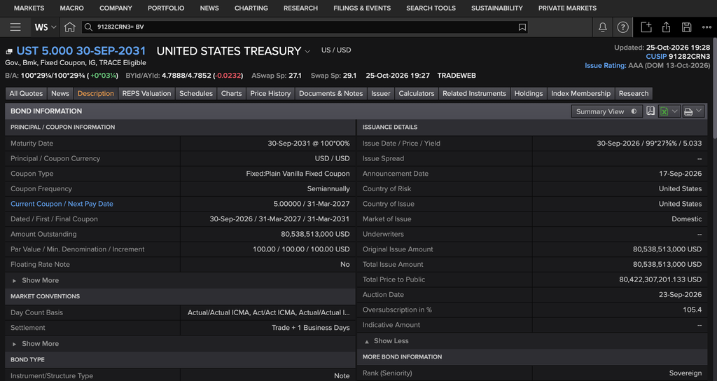

Bono del Tesoro a 5 años (US5YT=RR): rendimiento de 4.785%

[figure not shown]

Bono del Tesoro a 7 años (US7YT=RR): rendimiento de 4.869%

| Archivo en `datos/` | Pantalla de LSEG | Se usa en |
| --- | --- | --- |
| KO_price_history.xlsx | Price & Charts → Price History (2 años, diario) | Gráfica de precio y volatilidad |
| KO_FOV.pdf | KO.N FOV | Indicadores financieros y de deuda |
| KO_estados_financieros.xlsx | Financials (Income Statement, Balance Sheet, Cash Flow) | Respaldo de los indicadores |
| KO_bonos.xlsx | Debt & Credit → Debt Structure | Perfil de vencimientos, tasa del bono simple |
| KO_calificaciones.xlsx | Debt & Credit → Issuer Ratings | Calificación crediticia |
| KO_competidores.xlsx | Peers & Valuation | Comparación con competidores |